# cart cargo hanger heft problem

A cart is pulled along a level track by a string that runs over a pulley to a hanger. Some mass (cargo) rides on the cart, and some mass (heft) sits on the hanger. Ignore friction and the mass of the string.

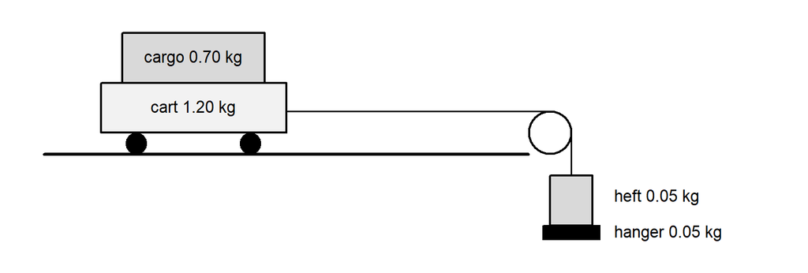

- The **forward force** is the weight of the hanger plus the heft.
- Weight is found by multiplying mass by 10 N/kg.
- The **total mass** being pushed forward is made of all four masses: cart, cargo, hanger, and heft.

What is the forward force (in N)?

What is the total mass (in kg)?

What is the acceleration of the cart (in m/s$^2$)?

The forward force is the weight of the hanger plus the heft. Their total mass is $0.05 + 0.05 = 0.10$ kg, so the weight is $0.10 \times 10 = 1$ N.

The total mass includes all four masses: $1.20 + 0.70 + 0.05 + 0.05 = 2.00$ kg.

The acceleration is the force divided by the total mass: $1 \div 2 = 0.5$ m/s$^2$.

- $(0.05 + 0.05) \times 10 = 1$ N
- $1.20 + 0.70 + 0.05 + 0.05 = 2.00$ kg
- $1 \div 2 = 0.5$ m/s$^2$

A cart is pulled along a level track by a string that runs over a pulley to a hanger. Some mass (cargo) rides on the cart, and some mass (heft) sits on the hanger. Ignore friction and the mass of the string.

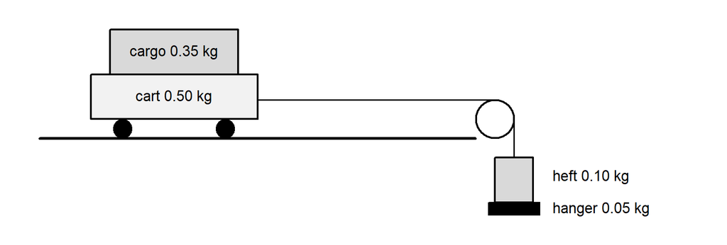

- The **forward force** is the weight of the hanger plus the heft.
- Weight is found by multiplying mass by 10 N/kg.
- The **total mass** being pushed forward is made of all four masses: cart, cargo, hanger, and heft.

What is the forward force (in N)?

What is the total mass (in kg)?

What is the acceleration of the cart (in m/s$^2$)?

The forward force is the weight of the hanger plus the heft. Their total mass is $0.05 + 0.10 = 0.15$ kg, so the weight is $0.15 \times 10 = 1.5$ N.

The total mass includes all four masses: $0.50 + 0.35 + 0.05 + 0.10 = 1.00$ kg.

The acceleration is the force divided by the total mass: $1.5 \div 1 = 1.5$ m/s$^2$.

- $(0.05 + 0.10) \times 10 = 1.5$ N
- $0.50 + 0.35 + 0.05 + 0.10 = 1.00$ kg
- $1.5 \div 1 = 1.5$ m/s$^2$

A cart is pulled along a level track by a string that runs over a pulley to a hanger. Some mass (cargo) rides on the cart, and some mass (heft) sits on the hanger. Ignore friction and the mass of the string.

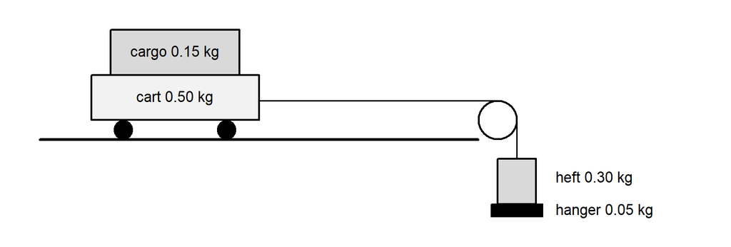

- The **forward force** is the weight of the hanger plus the heft.
- Weight is found by multiplying mass by 10 N/kg.
- The **total mass** being pushed forward is made of all four masses: cart, cargo, hanger, and heft.

What is the forward force (in N)?

What is the total mass (in kg)?

What is the acceleration of the cart (in m/s$^2$)?

The forward force is the weight of the hanger plus the heft. Their total mass is $0.05 + 0.30 = 0.35$ kg, so the weight is $0.35 \times 10 = 3.5$ N.

The total mass includes all four masses: $0.50 + 0.15 + 0.05 + 0.30 = 1.00$ kg.

The acceleration is the force divided by the total mass: $3.5 \div 1 = 3.5$ m/s$^2$.

- $(0.05 + 0.30) \times 10 = 3.5$ N
- $0.50 + 0.15 + 0.05 + 0.30 = 1.00$ kg
- $3.5 \div 1 = 3.5$ m/s$^2$

A cart is pulled along a level track by a string that runs over a pulley to a hanger. Some mass (cargo) rides on the cart, and some mass (heft) sits on the hanger. Ignore friction and the mass of the string.

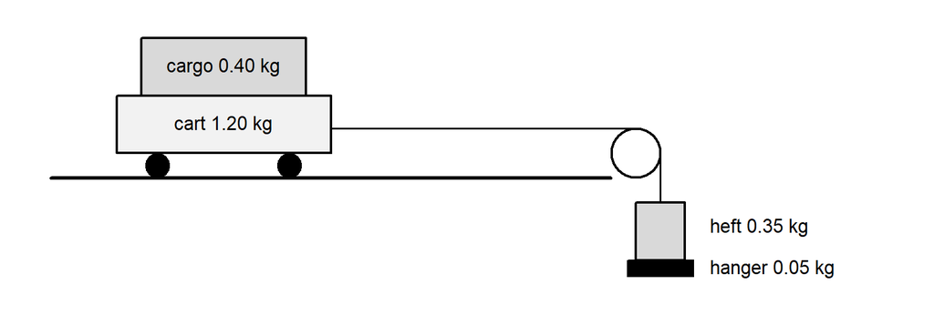

- The **forward force** is the weight of the hanger plus the heft.
- Weight is found by multiplying mass by 10 N/kg.
- The **total mass** being pushed forward is made of all four masses: cart, cargo, hanger, and heft.

What is the forward force (in N)?

What is the total mass (in kg)?

What is the acceleration of the cart (in m/s$^2$)?

The forward force is the weight of the hanger plus the heft. Their total mass is $0.05 + 0.35 = 0.40$ kg, so the weight is $0.40 \times 10 = 4$ N.

The total mass includes all four masses: $1.20 + 0.40 + 0.05 + 0.35 = 2.00$ kg.

The acceleration is the force divided by the total mass: $4 \div 2 = 2$ m/s$^2$.

- $(0.05 + 0.35) \times 10 = 4$ N
- $1.20 + 0.40 + 0.05 + 0.35 = 2.00$ kg
- $4 \div 2 = 2$ m/s$^2$

A cart is pulled along a level track by a string that runs over a pulley to a hanger. Some mass (cargo) rides on the cart, and some mass (heft) sits on the hanger. Ignore friction and the mass of the string.

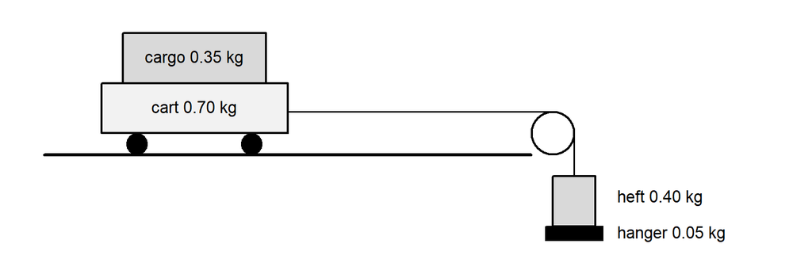

- The **forward force** is the weight of the hanger plus the heft.
- Weight is found by multiplying mass by 10 N/kg.
- The **total mass** being pushed forward is made of all four masses: cart, cargo, hanger, and heft.

What is the forward force (in N)?

What is the total mass (in kg)?

What is the acceleration of the cart (in m/s$^2$)?

The forward force is the weight of the hanger plus the heft. Their total mass is $0.05 + 0.40 = 0.45$ kg, so the weight is $0.45 \times 10 = 4.5$ N.

The total mass includes all four masses: $0.70 + 0.35 + 0.05 + 0.40 = 1.50$ kg.

The acceleration is the force divided by the total mass: $4.5 \div 1.5 = 3$ m/s$^2$.

- $(0.05 + 0.40) \times 10 = 4.5$ N
- $0.70 + 0.35 + 0.05 + 0.40 = 1.50$ kg
- $4.5 \div 1.5 = 3$ m/s$^2$

A cart is pulled along a level track by a string that runs over a pulley to a hanger. Some mass (cargo) rides on the cart, and some mass (heft) sits on the hanger. Ignore friction and the mass of the string.

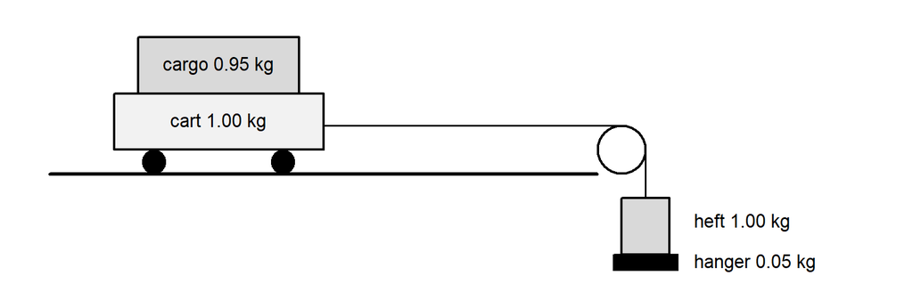

- The **forward force** is the weight of the hanger plus the heft.
- Weight is found by multiplying mass by 10 N/kg.
- The **total mass** being pushed forward is made of all four masses: cart, cargo, hanger, and heft.

What is the forward force (in N)?

What is the total mass (in kg)?

What is the acceleration of the cart (in m/s$^2$)?

The forward force is the weight of the hanger plus the heft. Their total mass is $0.05 + 1.00 = 1.05$ kg, so the weight is $1.05 \times 10 = 10.5$ N.

The total mass includes all four masses: $1.00 + 0.95 + 0.05 + 1.00 = 3.00$ kg.

The acceleration is the force divided by the total mass: $10.5 \div 3 = 3.5$ m/s$^2$.

- $(0.05 + 1.00) \times 10 = 10.5$ N
- $1.00 + 0.95 + 0.05 + 1.00 = 3.00$ kg
- $10.5 \div 3 = 3.5$ m/s$^2$

A cart is pulled along a level track by a string that runs over a pulley to a hanger. Some mass (cargo) rides on the cart, and some mass (heft) sits on the hanger. Ignore friction and the mass of the string.

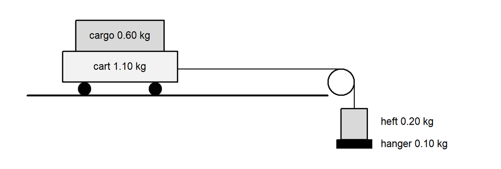

- The **forward force** is the weight of the hanger plus the heft.
- Weight is found by multiplying mass by 10 N/kg.
- The **total mass** being pushed forward is made of all four masses: cart, cargo, hanger, and heft.

What is the forward force (in N)?

What is the total mass (in kg)?

What is the acceleration of the cart (in m/s$^2$)?

The forward force is the weight of the hanger plus the heft. Their total mass is $0.10 + 0.20 = 0.30$ kg, so the weight is $0.30 \times 10 = 3$ N.

The total mass includes all four masses: $1.10 + 0.60 + 0.10 + 0.20 = 2.00$ kg.

The acceleration is the force divided by the total mass: $3 \div 2 = 1.5$ m/s$^2$.

- $(0.10 + 0.20) \times 10 = 3$ N
- $1.10 + 0.60 + 0.10 + 0.20 = 2.00$ kg
- $3 \div 2 = 1.5$ m/s$^2$

A cart is pulled along a level track by a string that runs over a pulley to a hanger. Some mass (cargo) rides on the cart, and some mass (heft) sits on the hanger. Ignore friction and the mass of the string.

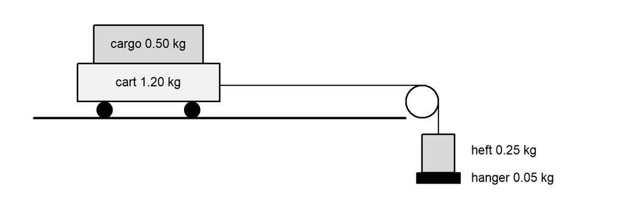

- The **forward force** is the weight of the hanger plus the heft.
- Weight is found by multiplying mass by 10 N/kg.
- The **total mass** being pushed forward is made of all four masses: cart, cargo, hanger, and heft.

What is the forward force (in N)?

What is the total mass (in kg)?

What is the acceleration of the cart (in m/s$^2$)?

The forward force is the weight of the hanger plus the heft. Their total mass is $0.05 + 0.25 = 0.30$ kg, so the weight is $0.30 \times 10 = 3$ N.

The total mass includes all four masses: $1.20 + 0.50 + 0.05 + 0.25 = 2.00$ kg.

The acceleration is the force divided by the total mass: $3 \div 2 = 1.5$ m/s$^2$.

- $(0.05 + 0.25) \times 10 = 3$ N
- $1.20 + 0.50 + 0.05 + 0.25 = 2.00$ kg
- $3 \div 2 = 1.5$ m/s$^2$

A cart is pulled along a level track by a string that runs over a pulley to a hanger. Some mass (cargo) rides on the cart, and some mass (heft) sits on the hanger. Ignore friction and the mass of the string.

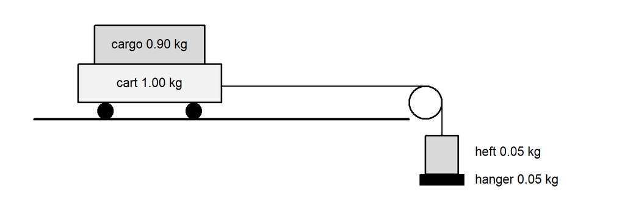

- The **forward force** is the weight of the hanger plus the heft.
- Weight is found by multiplying mass by 10 N/kg.
- The **total mass** being pushed forward is made of all four masses: cart, cargo, hanger, and heft.

What is the forward force (in N)?

What is the total mass (in kg)?

What is the acceleration of the cart (in m/s$^2$)?

The forward force is the weight of the hanger plus the heft. Their total mass is $0.05 + 0.05 = 0.10$ kg, so the weight is $0.10 \times 10 = 1$ N.

The total mass includes all four masses: $1.00 + 0.90 + 0.05 + 0.05 = 2.00$ kg.

The acceleration is the force divided by the total mass: $1 \div 2 = 0.5$ m/s$^2$.

- $(0.05 + 0.05) \times 10 = 1$ N
- $1.00 + 0.90 + 0.05 + 0.05 = 2.00$ kg
- $1 \div 2 = 0.5$ m/s$^2$

A cart is pulled along a level track by a string that runs over a pulley to a hanger. Some mass (cargo) rides on the cart, and some mass (heft) sits on the hanger. Ignore friction and the mass of the string.

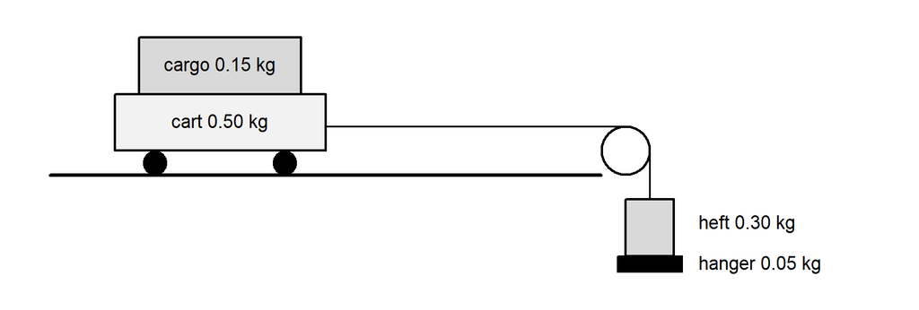

- The **forward force** is the weight of the hanger plus the heft.
- Weight is found by multiplying mass by 10 N/kg.
- The **total mass** being pushed forward is made of all four masses: cart, cargo, hanger, and heft.

What is the forward force (in N)?

What is the total mass (in kg)?

What is the acceleration of the cart (in m/s$^2$)?

The forward force is the weight of the hanger plus the heft. Their total mass is $0.05 + 0.30 = 0.35$ kg, so the weight is $0.35 \times 10 = 3.5$ N.

The total mass includes all four masses: $0.50 + 0.15 + 0.05 + 0.30 = 1.00$ kg.

The acceleration is the force divided by the total mass: $3.5 \div 1 = 3.5$ m/s$^2$.

- $(0.05 + 0.30) \times 10 = 3.5$ N
- $0.50 + 0.15 + 0.05 + 0.30 = 1.00$ kg
- $3.5 \div 1 = 3.5$ m/s$^2$

A cart is pulled along a level track by a string that runs over a pulley to a hanger. Some mass (cargo) rides on the cart, and some mass (heft) sits on the hanger. Ignore friction and the mass of the string.

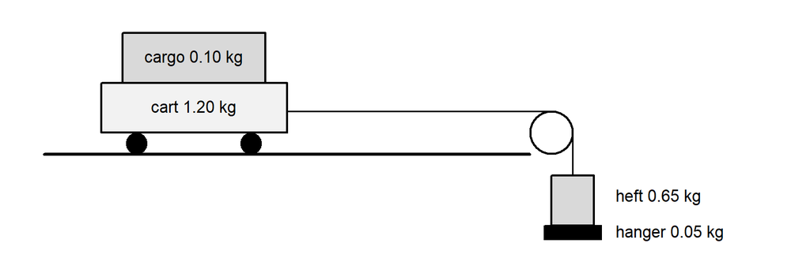

- The **forward force** is the weight of the hanger plus the heft.
- Weight is found by multiplying mass by 10 N/kg.
- The **total mass** being pushed forward is made of all four masses: cart, cargo, hanger, and heft.

What is the forward force (in N)?

What is the total mass (in kg)?

What is the acceleration of the cart (in m/s$^2$)?

The forward force is the weight of the hanger plus the heft. Their total mass is $0.05 + 0.65 = 0.70$ kg, so the weight is $0.70 \times 10 = 7$ N.

The total mass includes all four masses: $1.20 + 0.10 + 0.05 + 0.65 = 2.00$ kg.

The acceleration is the force divided by the total mass: $7 \div 2 = 3.5$ m/s$^2$.

- $(0.05 + 0.65) \times 10 = 7$ N
- $1.20 + 0.10 + 0.05 + 0.65 = 2.00$ kg
- $7 \div 2 = 3.5$ m/s$^2$

A cart is pulled along a level track by a string that runs over a pulley to a hanger. Some mass (cargo) rides on the cart, and some mass (heft) sits on the hanger. Ignore friction and the mass of the string.

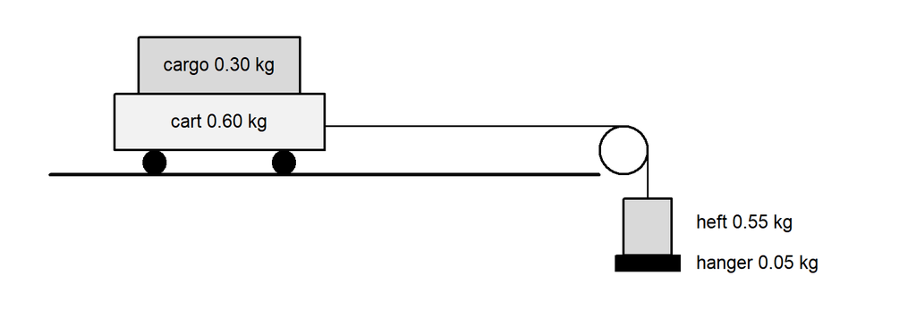

- The **forward force** is the weight of the hanger plus the heft.
- Weight is found by multiplying mass by 10 N/kg.
- The **total mass** being pushed forward is made of all four masses: cart, cargo, hanger, and heft.

What is the forward force (in N)?

What is the total mass (in kg)?

What is the acceleration of the cart (in m/s$^2$)?

The forward force is the weight of the hanger plus the heft. Their total mass is $0.05 + 0.55 = 0.60$ kg, so the weight is $0.60 \times 10 = 6$ N.

The total mass includes all four masses: $0.60 + 0.30 + 0.05 + 0.55 = 1.50$ kg.

The acceleration is the force divided by the total mass: $6 \div 1.5 = 4$ m/s$^2$.

- $(0.05 + 0.55) \times 10 = 6$ N
- $0.60 + 0.30 + 0.05 + 0.55 = 1.50$ kg
- $6 \div 1.5 = 4$ m/s$^2$

A cart is pulled along a level track by a string that runs over a pulley to a hanger. Some mass (cargo) rides on the cart, and some mass (heft) sits on the hanger. Ignore friction and the mass of the string.

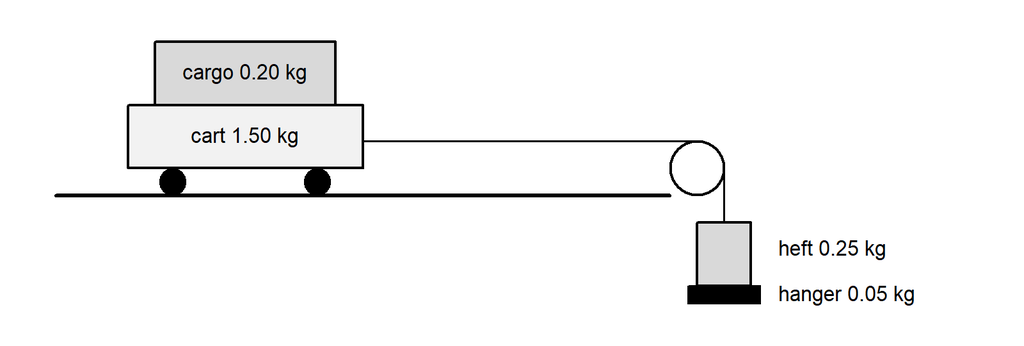

- The **forward force** is the weight of the hanger plus the heft.
- Weight is found by multiplying mass by 10 N/kg.
- The **total mass** being pushed forward is made of all four masses: cart, cargo, hanger, and heft.

What is the forward force (in N)?

What is the total mass (in kg)?

What is the acceleration of the cart (in m/s$^2$)?

The forward force is the weight of the hanger plus the heft. Their total mass is $0.05 + 0.25 = 0.30$ kg, so the weight is $0.30 \times 10 = 3$ N.

The total mass includes all four masses: $1.50 + 0.20 + 0.05 + 0.25 = 2.00$ kg.

The acceleration is the force divided by the total mass: $3 \div 2 = 1.5$ m/s$^2$.

- $(0.05 + 0.25) \times 10 = 3$ N
- $1.50 + 0.20 + 0.05 + 0.25 = 2.00$ kg
- $3 \div 2 = 1.5$ m/s$^2$

A cart is pulled along a level track by a string that runs over a pulley to a hanger. Some mass (cargo) rides on the cart, and some mass (heft) sits on the hanger. Ignore friction and the mass of the string.

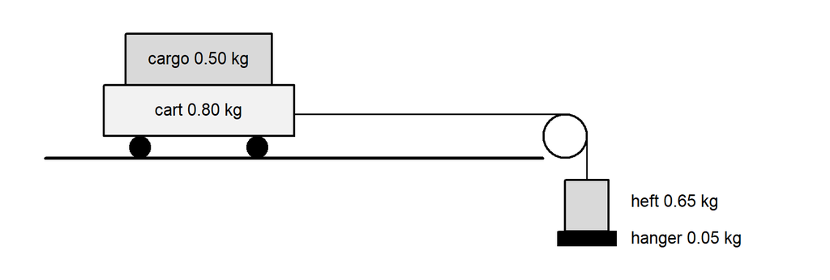

- The **forward force** is the weight of the hanger plus the heft.
- Weight is found by multiplying mass by 10 N/kg.
- The **total mass** being pushed forward is made of all four masses: cart, cargo, hanger, and heft.

What is the forward force (in N)?

What is the total mass (in kg)?

What is the acceleration of the cart (in m/s$^2$)?

The forward force is the weight of the hanger plus the heft. Their total mass is $0.05 + 0.65 = 0.70$ kg, so the weight is $0.70 \times 10 = 7$ N.

The total mass includes all four masses: $0.80 + 0.50 + 0.05 + 0.65 = 2.00$ kg.

The acceleration is the force divided by the total mass: $7 \div 2 = 3.5$ m/s$^2$.

- $(0.05 + 0.65) \times 10 = 7$ N
- $0.80 + 0.50 + 0.05 + 0.65 = 2.00$ kg
- $7 \div 2 = 3.5$ m/s$^2$

A cart is pulled along a level track by a string that runs over a pulley to a hanger. Some mass (cargo) rides on the cart, and some mass (heft) sits on the hanger. Ignore friction and the mass of the string.

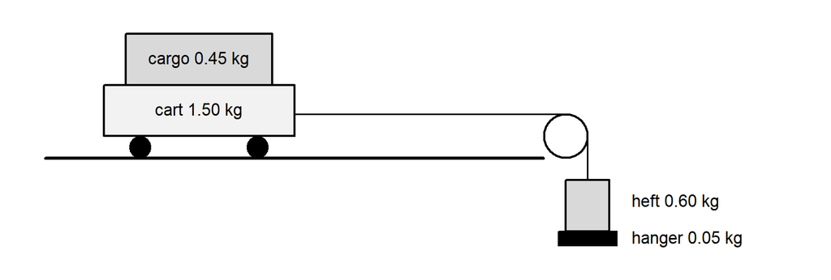

- The **forward force** is the weight of the hanger plus the heft.
- Weight is found by multiplying mass by 10 N/kg.
- The **total mass** being pushed forward is made of all four masses: cart, cargo, hanger, and heft.

What is the forward force (in N)?

What is the total mass (in kg)?

What is the acceleration of the cart (in m/s$^2$)?

The forward force is the weight of the hanger plus the heft. Their total mass is $0.05 + 0.60 = 0.65$ kg, so the weight is $0.65 \times 10 = 6.5$ N.

The total mass includes all four masses: $1.50 + 0.45 + 0.05 + 0.60 = 2.60$ kg.

The acceleration is the force divided by the total mass: $6.5 \div 2.6 = 2.5$ m/s$^2$.

- $(0.05 + 0.60) \times 10 = 6.5$ N
- $1.50 + 0.45 + 0.05 + 0.60 = 2.60$ kg
- $6.5 \div 2.6 = 2.5$ m/s$^2$

A cart is pulled along a level track by a string that runs over a pulley to a hanger. Some mass (cargo) rides on the cart, and some mass (heft) sits on the hanger. Ignore friction and the mass of the string.

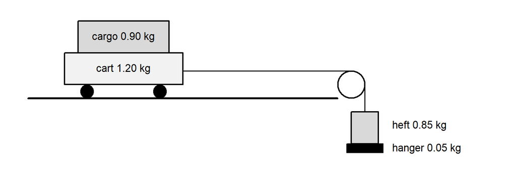

- The **forward force** is the weight of the hanger plus the heft.
- Weight is found by multiplying mass by 10 N/kg.
- The **total mass** being pushed forward is made of all four masses: cart, cargo, hanger, and heft.

What is the forward force (in N)?

What is the total mass (in kg)?

What is the acceleration of the cart (in m/s$^2$)?

The forward force is the weight of the hanger plus the heft. Their total mass is $0.05 + 0.85 = 0.90$ kg, so the weight is $0.90 \times 10 = 9$ N.

The total mass includes all four masses: $1.20 + 0.90 + 0.05 + 0.85 = 3.00$ kg.

The acceleration is the force divided by the total mass: $9 \div 3 = 3$ m/s$^2$.

- $(0.05 + 0.85) \times 10 = 9$ N
- $1.20 + 0.90 + 0.05 + 0.85 = 3.00$ kg
- $9 \div 3 = 3$ m/s$^2$

A cart is pulled along a level track by a string that runs over a pulley to a hanger. Some mass (cargo) rides on the cart, and some mass (heft) sits on the hanger. Ignore friction and the mass of the string.

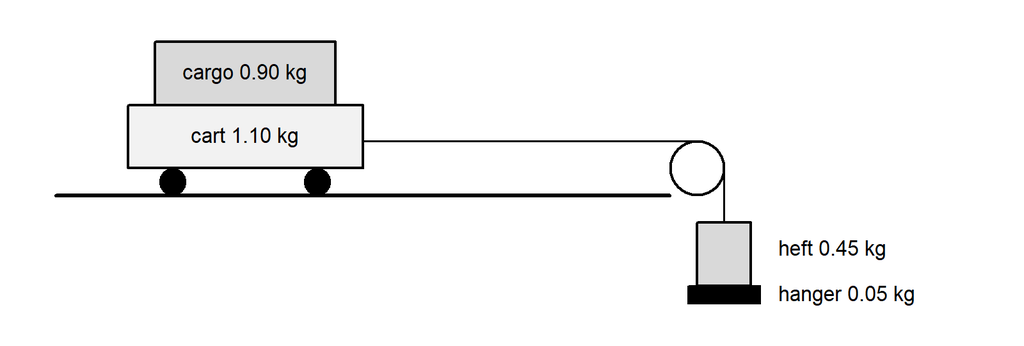

- The **forward force** is the weight of the hanger plus the heft.
- Weight is found by multiplying mass by 10 N/kg.
- The **total mass** being pushed forward is made of all four masses: cart, cargo, hanger, and heft.

What is the forward force (in N)?

What is the total mass (in kg)?

What is the acceleration of the cart (in m/s$^2$)?

The forward force is the weight of the hanger plus the heft. Their total mass is $0.05 + 0.45 = 0.50$ kg, so the weight is $0.50 \times 10 = 5$ N.

The total mass includes all four masses: $1.10 + 0.90 + 0.05 + 0.45 = 2.50$ kg.

The acceleration is the force divided by the total mass: $5 \div 2.5 = 2$ m/s$^2$.

- $(0.05 + 0.45) \times 10 = 5$ N
- $1.10 + 0.90 + 0.05 + 0.45 = 2.50$ kg
- $5 \div 2.5 = 2$ m/s$^2$

A cart is pulled along a level track by a string that runs over a pulley to a hanger. Some mass (cargo) rides on the cart, and some mass (heft) sits on the hanger. Ignore friction and the mass of the string.

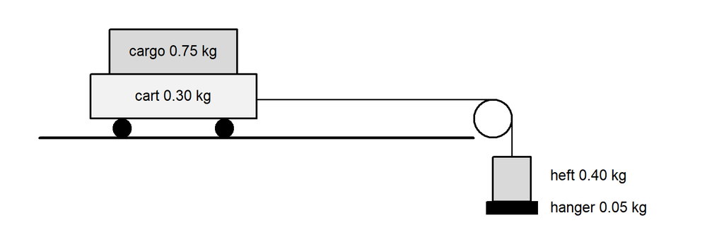

- The **forward force** is the weight of the hanger plus the heft.
- Weight is found by multiplying mass by 10 N/kg.
- The **total mass** being pushed forward is made of all four masses: cart, cargo, hanger, and heft.

What is the forward force (in N)?

What is the total mass (in kg)?

What is the acceleration of the cart (in m/s$^2$)?

The forward force is the weight of the hanger plus the heft. Their total mass is $0.05 + 0.40 = 0.45$ kg, so the weight is $0.45 \times 10 = 4.5$ N.

The total mass includes all four masses: $0.30 + 0.75 + 0.05 + 0.40 = 1.50$ kg.

The acceleration is the force divided by the total mass: $4.5 \div 1.5 = 3$ m/s$^2$.

- $(0.05 + 0.40) \times 10 = 4.5$ N
- $0.30 + 0.75 + 0.05 + 0.40 = 1.50$ kg
- $4.5 \div 1.5 = 3$ m/s$^2$

A cart is pulled along a level track by a string that runs over a pulley to a hanger. Some mass (cargo) rides on the cart, and some mass (heft) sits on the hanger. Ignore friction and the mass of the string.

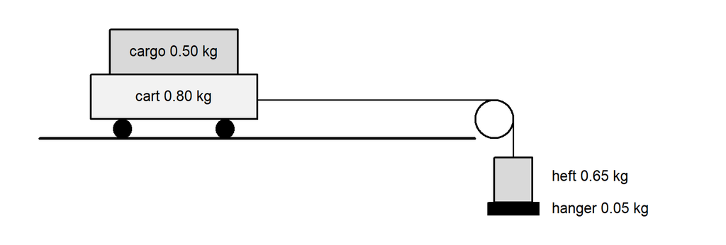

- The **forward force** is the weight of the hanger plus the heft.
- Weight is found by multiplying mass by 10 N/kg.
- The **total mass** being pushed forward is made of all four masses: cart, cargo, hanger, and heft.

What is the forward force (in N)?

What is the total mass (in kg)?

What is the acceleration of the cart (in m/s$^2$)?

The forward force is the weight of the hanger plus the heft. Their total mass is $0.05 + 0.65 = 0.70$ kg, so the weight is $0.70 \times 10 = 7$ N.

The total mass includes all four masses: $0.80 + 0.50 + 0.05 + 0.65 = 2.00$ kg.

The acceleration is the force divided by the total mass: $7 \div 2 = 3.5$ m/s$^2$.

- $(0.05 + 0.65) \times 10 = 7$ N
- $0.80 + 0.50 + 0.05 + 0.65 = 2.00$ kg
- $7 \div 2 = 3.5$ m/s$^2$

A cart is pulled along a level track by a string that runs over a pulley to a hanger. Some mass (cargo) rides on the cart, and some mass (heft) sits on the hanger. Ignore friction and the mass of the string.

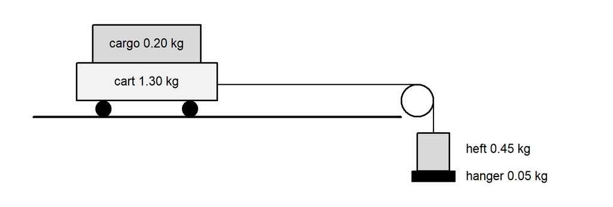

- The **forward force** is the weight of the hanger plus the heft.
- Weight is found by multiplying mass by 10 N/kg.
- The **total mass** being pushed forward is made of all four masses: cart, cargo, hanger, and heft.

What is the forward force (in N)?

What is the total mass (in kg)?

What is the acceleration of the cart (in m/s$^2$)?

The forward force is the weight of the hanger plus the heft. Their total mass is $0.05 + 0.45 = 0.50$ kg, so the weight is $0.50 \times 10 = 5$ N.

The total mass includes all four masses: $1.30 + 0.20 + 0.05 + 0.45 = 2.00$ kg.

The acceleration is the force divided by the total mass: $5 \div 2 = 2.5$ m/s$^2$.

- $(0.05 + 0.45) \times 10 = 5$ N
- $1.30 + 0.20 + 0.05 + 0.45 = 2.00$ kg
- $5 \div 2 = 2.5$ m/s$^2$

A cart is pulled along a level track by a string that runs over a pulley to a hanger. Some mass (cargo) rides on the cart, and some mass (heft) sits on the hanger. Ignore friction and the mass of the string.

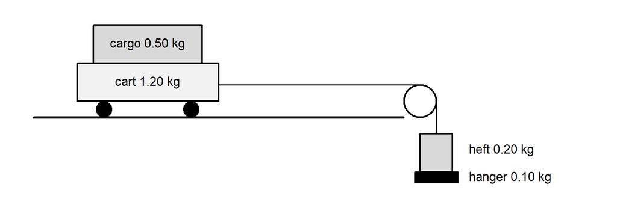

- The **forward force** is the weight of the hanger plus the heft.
- Weight is found by multiplying mass by 10 N/kg.
- The **total mass** being pushed forward is made of all four masses: cart, cargo, hanger, and heft.

What is the forward force (in N)?

What is the total mass (in kg)?

What is the acceleration of the cart (in m/s$^2$)?

The forward force is the weight of the hanger plus the heft. Their total mass is $0.10 + 0.20 = 0.30$ kg, so the weight is $0.30 \times 10 = 3$ N.

The total mass includes all four masses: $1.20 + 0.50 + 0.10 + 0.20 = 2.00$ kg.

The acceleration is the force divided by the total mass: $3 \div 2 = 1.5$ m/s$^2$.

- $(0.10 + 0.20) \times 10 = 3$ N
- $1.20 + 0.50 + 0.10 + 0.20 = 2.00$ kg
- $3 \div 2 = 1.5$ m/s$^2$

A cart is pulled along a level track by a string that runs over a pulley to a hanger. Some mass (cargo) rides on the cart, and some mass (heft) sits on the hanger. Ignore friction and the mass of the string.

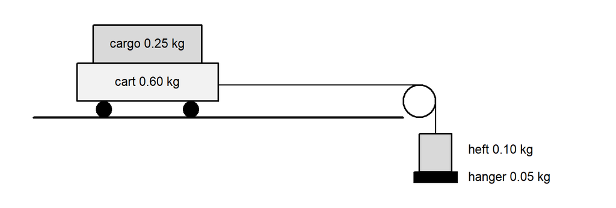

- The **forward force** is the weight of the hanger plus the heft.
- Weight is found by multiplying mass by 10 N/kg.
- The **total mass** being pushed forward is made of all four masses: cart, cargo, hanger, and heft.

What is the forward force (in N)?

What is the total mass (in kg)?

What is the acceleration of the cart (in m/s$^2$)?

The forward force is the weight of the hanger plus the heft. Their total mass is $0.05 + 0.10 = 0.15$ kg, so the weight is $0.15 \times 10 = 1.5$ N.

The total mass includes all four masses: $0.60 + 0.25 + 0.05 + 0.10 = 1.00$ kg.

The acceleration is the force divided by the total mass: $1.5 \div 1 = 1.5$ m/s$^2$.

- $(0.05 + 0.10) \times 10 = 1.5$ N
- $0.60 + 0.25 + 0.05 + 0.10 = 1.00$ kg
- $1.5 \div 1 = 1.5$ m/s$^2$

A cart is pulled along a level track by a string that runs over a pulley to a hanger. Some mass (cargo) rides on the cart, and some mass (heft) sits on the hanger. Ignore friction and the mass of the string.

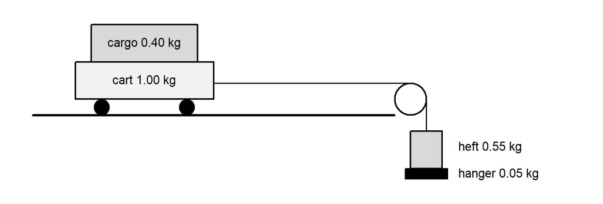

- The **forward force** is the weight of the hanger plus the heft.
- Weight is found by multiplying mass by 10 N/kg.
- The **total mass** being pushed forward is made of all four masses: cart, cargo, hanger, and heft.

What is the forward force (in N)?

What is the total mass (in kg)?

What is the acceleration of the cart (in m/s$^2$)?

The forward force is the weight of the hanger plus the heft. Their total mass is $0.05 + 0.55 = 0.60$ kg, so the weight is $0.60 \times 10 = 6$ N.

The total mass includes all four masses: $1.00 + 0.40 + 0.05 + 0.55 = 2.00$ kg.

The acceleration is the force divided by the total mass: $6 \div 2 = 3$ m/s$^2$.

- $(0.05 + 0.55) \times 10 = 6$ N
- $1.00 + 0.40 + 0.05 + 0.55 = 2.00$ kg
- $6 \div 2 = 3$ m/s$^2$

A cart is pulled along a level track by a string that runs over a pulley to a hanger. Some mass (cargo) rides on the cart, and some mass (heft) sits on the hanger. Ignore friction and the mass of the string.

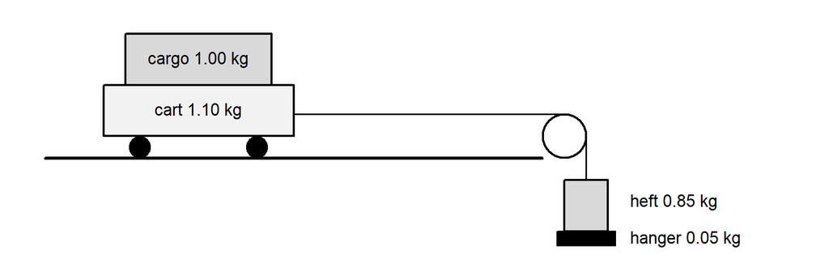

- The **forward force** is the weight of the hanger plus the heft.
- Weight is found by multiplying mass by 10 N/kg.
- The **total mass** being pushed forward is made of all four masses: cart, cargo, hanger, and heft.

What is the forward force (in N)?

What is the total mass (in kg)?

What is the acceleration of the cart (in m/s$^2$)?

The forward force is the weight of the hanger plus the heft. Their total mass is $0.05 + 0.85 = 0.90$ kg, so the weight is $0.90 \times 10 = 9$ N.

The total mass includes all four masses: $1.10 + 1.00 + 0.05 + 0.85 = 3.00$ kg.

The acceleration is the force divided by the total mass: $9 \div 3 = 3$ m/s$^2$.

- $(0.05 + 0.85) \times 10 = 9$ N
- $1.10 + 1.00 + 0.05 + 0.85 = 3.00$ kg
- $9 \div 3 = 3$ m/s$^2$

A cart is pulled along a level track by a string that runs over a pulley to a hanger. Some mass (cargo) rides on the cart, and some mass (heft) sits on the hanger. Ignore friction and the mass of the string.

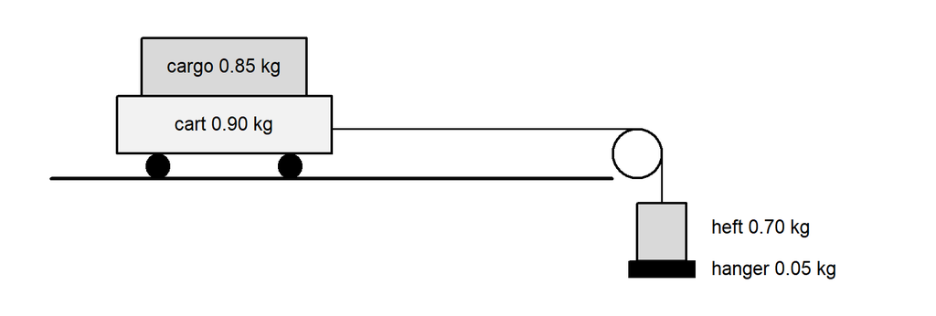

- The **forward force** is the weight of the hanger plus the heft.
- Weight is found by multiplying mass by 10 N/kg.
- The **total mass** being pushed forward is made of all four masses: cart, cargo, hanger, and heft.

What is the forward force (in N)?

What is the total mass (in kg)?

What is the acceleration of the cart (in m/s$^2$)?

The forward force is the weight of the hanger plus the heft. Their total mass is $0.05 + 0.70 = 0.75$ kg, so the weight is $0.75 \times 10 = 7.5$ N.

The total mass includes all four masses: $0.90 + 0.85 + 0.05 + 0.70 = 2.50$ kg.

The acceleration is the force divided by the total mass: $7.5 \div 2.5 = 3$ m/s$^2$.

- $(0.05 + 0.70) \times 10 = 7.5$ N
- $0.90 + 0.85 + 0.05 + 0.70 = 2.50$ kg
- $7.5 \div 2.5 = 3$ m/s$^2$

A cart is pulled along a level track by a string that runs over a pulley to a hanger. Some mass (cargo) rides on the cart, and some mass (heft) sits on the hanger. Ignore friction and the mass of the string.

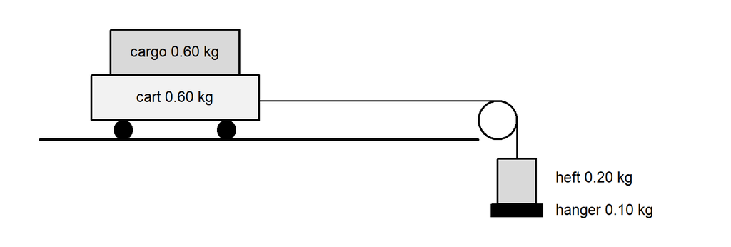

- The **forward force** is the weight of the hanger plus the heft.
- Weight is found by multiplying mass by 10 N/kg.
- The **total mass** being pushed forward is made of all four masses: cart, cargo, hanger, and heft.

What is the forward force (in N)?

What is the total mass (in kg)?

What is the acceleration of the cart (in m/s$^2$)?

The forward force is the weight of the hanger plus the heft. Their total mass is $0.10 + 0.20 = 0.30$ kg, so the weight is $0.30 \times 10 = 3$ N.

The total mass includes all four masses: $0.60 + 0.60 + 0.10 + 0.20 = 1.50$ kg.

The acceleration is the force divided by the total mass: $3 \div 1.5 = 2$ m/s$^2$.

- $(0.10 + 0.20) \times 10 = 3$ N
- $0.60 + 0.60 + 0.10 + 0.20 = 1.50$ kg
- $3 \div 1.5 = 2$ m/s$^2$

A cart is pulled along a level track by a string that runs over a pulley to a hanger. Some mass (cargo) rides on the cart, and some mass (heft) sits on the hanger. Ignore friction and the mass of the string.

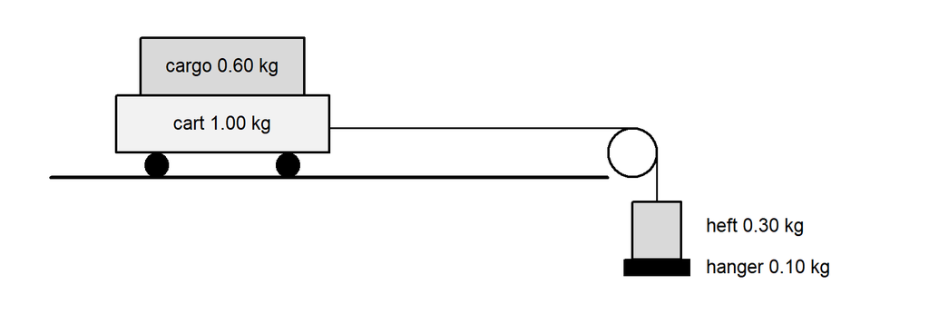

- The **forward force** is the weight of the hanger plus the heft.
- Weight is found by multiplying mass by 10 N/kg.
- The **total mass** being pushed forward is made of all four masses: cart, cargo, hanger, and heft.

What is the forward force (in N)?

What is the total mass (in kg)?

What is the acceleration of the cart (in m/s$^2$)?

The forward force is the weight of the hanger plus the heft. Their total mass is $0.10 + 0.30 = 0.40$ kg, so the weight is $0.40 \times 10 = 4$ N.

The total mass includes all four masses: $1.00 + 0.60 + 0.10 + 0.30 = 2.00$ kg.

The acceleration is the force divided by the total mass: $4 \div 2 = 2$ m/s$^2$.

- $(0.10 + 0.30) \times 10 = 4$ N
- $1.00 + 0.60 + 0.10 + 0.30 = 2.00$ kg
- $4 \div 2 = 2$ m/s$^2$

A cart is pulled along a level track by a string that runs over a pulley to a hanger. Some mass (cargo) rides on the cart, and some mass (heft) sits on the hanger. Ignore friction and the mass of the string.

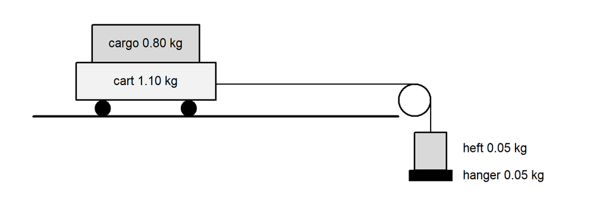

- The **forward force** is the weight of the hanger plus the heft.
- Weight is found by multiplying mass by 10 N/kg.
- The **total mass** being pushed forward is made of all four masses: cart, cargo, hanger, and heft.

What is the forward force (in N)?

What is the total mass (in kg)?

What is the acceleration of the cart (in m/s$^2$)?

The forward force is the weight of the hanger plus the heft. Their total mass is $0.05 + 0.05 = 0.10$ kg, so the weight is $0.10 \times 10 = 1$ N.

The total mass includes all four masses: $1.10 + 0.80 + 0.05 + 0.05 = 2.00$ kg.

The acceleration is the force divided by the total mass: $1 \div 2 = 0.5$ m/s$^2$.

- $(0.05 + 0.05) \times 10 = 1$ N
- $1.10 + 0.80 + 0.05 + 0.05 = 2.00$ kg
- $1 \div 2 = 0.5$ m/s$^2$

A cart is pulled along a level track by a string that runs over a pulley to a hanger. Some mass (cargo) rides on the cart, and some mass (heft) sits on the hanger. Ignore friction and the mass of the string.

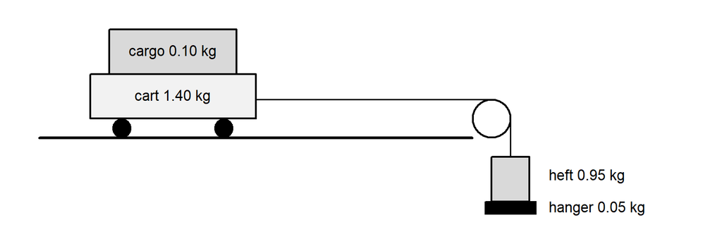

- The **forward force** is the weight of the hanger plus the heft.
- Weight is found by multiplying mass by 10 N/kg.
- The **total mass** being pushed forward is made of all four masses: cart, cargo, hanger, and heft.

What is the forward force (in N)?

What is the total mass (in kg)?

What is the acceleration of the cart (in m/s$^2$)?

The forward force is the weight of the hanger plus the heft. Their total mass is $0.05 + 0.95 = 1.00$ kg, so the weight is $1.00 \times 10 = 10$ N.

The total mass includes all four masses: $1.40 + 0.10 + 0.05 + 0.95 = 2.50$ kg.

The acceleration is the force divided by the total mass: $10 \div 2.5 = 4$ m/s$^2$.

- $(0.05 + 0.95) \times 10 = 10$ N
- $1.40 + 0.10 + 0.05 + 0.95 = 2.50$ kg
- $10 \div 2.5 = 4$ m/s$^2$

A cart is pulled along a level track by a string that runs over a pulley to a hanger. Some mass (cargo) rides on the cart, and some mass (heft) sits on the hanger. Ignore friction and the mass of the string.

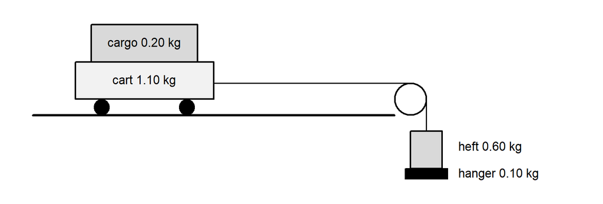

- The **forward force** is the weight of the hanger plus the heft.
- Weight is found by multiplying mass by 10 N/kg.
- The **total mass** being pushed forward is made of all four masses: cart, cargo, hanger, and heft.

What is the forward force (in N)?

What is the total mass (in kg)?

What is the acceleration of the cart (in m/s$^2$)?

The forward force is the weight of the hanger plus the heft. Their total mass is $0.10 + 0.60 = 0.70$ kg, so the weight is $0.70 \times 10 = 7$ N.

The total mass includes all four masses: $1.10 + 0.20 + 0.10 + 0.60 = 2.00$ kg.

The acceleration is the force divided by the total mass: $7 \div 2 = 3.5$ m/s$^2$.

- $(0.10 + 0.60) \times 10 = 7$ N
- $1.10 + 0.20 + 0.10 + 0.60 = 2.00$ kg
- $7 \div 2 = 3.5$ m/s$^2$